# Project 1

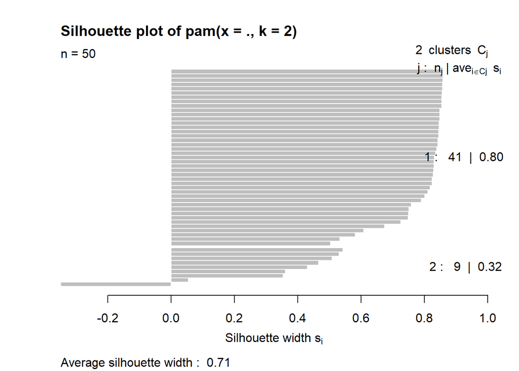

```r
#interpreting Average Silhouette Width
pam1<- variables%>%pam(2)
plot(pam1, which=2)
```

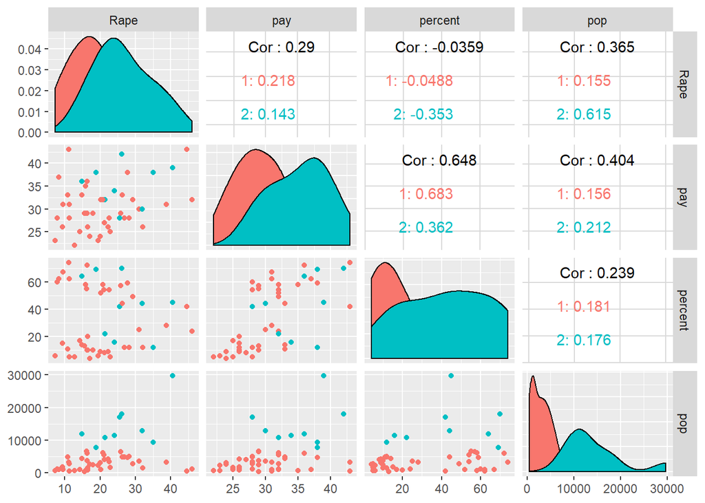

```r
library(GGally)

#visualize pairwise combinations
pamclust<-variables%>%ungroup%>%mutate(cluster=as.factor(pam1$clustering))
pamclust%>% ggpairs(columns = c(1,2,3,4), aes(color=cluster))
```

I created a smaller dataset of just Rape, pay, percent, and pop variables to analyze since I think they might have interesting results to look at. Then, I chose a cluster of 2 by running mean silhouette width, and the highest peak in the plot was 2 for k. The average silhouette width was 0.71, indicating that a strong structure has been found. I then created a visualization of all the possible pair of combination to compare between those 4 variables. All pairs have weak positive correlation except percent (of high school stdents in the state who took the SAT exam) with Rape Arrests, which had a weak very negative correlation. Percent (of high school stdents in the state who took the SAT exam) and pay (average teacher’s salary) have a higher positive correlation than the other combination pairs.